# Doing Math with Python

**Amit Saha**

May 29, PyCon US 2016 Education Summit

Portland, Oregon

## About me

- Software Engineer at [Freelancer.com](https://www.freelancer.com) HQ in Sydney, Australia
- Author of "Doing Math with Python" (No Starch Press, 2015)
- Writes for Linux Voice, Linux Journal, and others.
- [Blog](http://echorand.me), [GitHub](http://github.com/amitsaha)

#### Contact

- [@echorand](http://twitter.com/echorand)
- Email

Slides: https://doingmathwithpython.github.io/pycon-us-2016/

All presentation materials: https://github.com/doingmathwithpython

### This talk - a proposal, a hypothesis, a statement

What? *Python can lead to a more enriching learning and teaching experience in the classroom*

How? *Next slides*

### Tools (or, Giant shoulders we will stand on)

[figure not shown]

*Python 3*, *SymPy*, *matplotlib*

*Individual logos are copyright of the respective projects. [Source](http://www.orphancaremovement.org/standing-on-the-shoulder-of-giants/) of the "giant shoulders" image.

### Python - a scientific calculator

Whose calculator looks like this?

```
>>> (131 + 21.5 + 100.2 + 88.7 + 99.5 + 100.5 + 200.5)/4
185.475
```

*Python 3 is my favorite calculator (not Python 2 because 1/2 = 0)*

Beyond basic operations:

- `fabs()`, `abs()`, `sin()`, `cos()`, `gcd()`, `log()` and more (See [math](https://docs.python.org/3/library/math.html))
- Descriptive statistics (See statistics)

### Python - a scientific calculator

- Develop your own functions: unit conversion, finding correlation, .., anything really
- Use PYTHONSTARTUP to extend the battery of readily available mathematical functions

```
$ PYTHONSTARTUP=~/work/dmwp/pycon-us-2016/startup_math.py idle3 -s
```

### Unit conversion functions

```
>>> unit_conversion()
1. Kilometers to Miles
2. Miles to Kilometers
3. Kilograms to Pounds
4. Pounds to Kilograms
5. Celsius to Fahrenheit
6. Fahrenheit to Celsius
Which conversion would you like to do? 6
Enter temperature in fahrenheit: 98
Temperature in celsius: 36.66666666666667
>>>
```

### Finding linear correlation

```
>>>
>>> x = [1, 2, 3, 4]
>>> y = [2, 4, 6.1, 7.9]
>>> find_corr_x_y(x, y)
0.9995411791453812
```

### Python - a really fancy calculator

SymPy - a pure Python symbolic math library

*from sympy import awesomeness* - don't try that :)

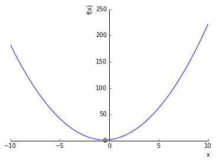

```python
# Create graphs from algebraic expressions

from sympy import Symbol, plot
x = Symbol('x')
p = plot(2*x**2 + 2*x + 2)
```

```python
# Solve equations

from sympy import solve, Symbol
x = Symbol('x')
solve(2*x + 1)
```

```
[-1/2]
```

```python
# Limits

from sympy import Symbol, Limit, sin
x = Symbol('x')
Limit(sin(x)/x, x, 0).doit()
```

```
1
```

```python
# Derivative

from sympy import Symbol, Derivative, sin, init_printing
x = Symbol('x')
init_printing()
Derivative(sin(x)**(2*x+1), x).doit()
```

$$\left(\frac{\left(2 x + 1\right) \cos{\left (x \right )}}{\sin{\left (x \right )}} + 2 \log{\left (\sin{\left (x \right )} \right )}\right) \sin^{2 x + 1}{\left (x \right )}$$

```python
# Indefinite integral

from sympy import Symbol, Integral, sqrt, sin, init_printing
x = Symbol('x')
init_printing()
Integral(sqrt(x)).doit()
```

$$\frac{2 x^{\frac{3}{2}}}{3}$$

```python
# Definite integral

from sympy import Symbol, Integral, sqrt
x = Symbol('x')
Integral(sqrt(x), (x, 0, 2)).doit()
```

$$\frac{4 \sqrt{2}}{3}$$

# Can we do more than write smart calculators?

### Python - Making other subjects more lively

[figure not shown]

- matplotlib
- basemap
- Interactive Jupyter Notebooks

#### Bringing Science to life

*Animation of a Projectile motion* [(Python Source)](https://github.com/doingmathwithpython/pycon-us-2016/blob/master/py-files/projectile_animation.py)

```python
from IPython.display import YouTubeVideo
YouTubeVideo("8uWRVh58KdQ")
```

[video not shown]

#### Exploring Fractals in Nature

*Interactively drawing a Barnsley Fern* [(Notebook)](https://github.com/doingmathwithpython/pycon-us-2016/blob/master/notebooks/Interactive%20Barnsley%20Fern.ipynb)

[figure not shown]

#### The world is your graph paper

*Showing places on a digital map* [(Notebook)](https://github.com/doingmathwithpython/pycon-us-2016/blob/master/notebooks/Maps%20using%20Basemap%20-%20demo.ipynb)

### Book: Doing Math With Python

[figure not shown]

Overview

- All of what I have discussed so far
- In addition: Descriptive statistics, Sets and Probability, Random numbers

Published by [No Starch Press](https://www.nostarch.com/doingmathwithpython) in August, 2015.

*Upcoming/In-progress translations*: Simplified Chinese, Japanese, French and Korean.

#### Comments

> Saha does an excellent job providing a clear link between Python and upper-level math concepts, and demonstrates how Python can be transformed into a mathematical stage. This book deserves a spot on every geometry teacher’s bookshelf.

[School Library Journal](http://www.slj.com/2016/05/collection-development/read-watch-alikes/coding-lets-begin/#_)

> Outstanding guide to using Python to do maths. Working back through my undergrad maths using Python.

> Saha does an excellent job providing a clear link between Python and upper-level math concepts, and demonstrates how Python can be transformed into a mathematical stage.

> This book is highly recommended for the high school or college student and anyone who is looking for a more natural way of programming math and scientific functions

> As a teacher I highly recommend this book as a way to work with someone in learning both math and programming

### Great base for the future

*Statistics and Graphing data* -> *Data Science*

*Differential Calculus* -> *Machine learning*

### Application of differentiation

Use gradient descent to find a function's minimum value [(Notebook)](https://github.com/doingmathwithpython/pycon-us-2016/blob/master/notebooks/Gradient%20Descent.ipynb)

### Predict the college admission score based on high school math score

Use gradient descent as the optimizer for single variable linear regression model [(Notebook)](https://github.com/doingmathwithpython/pycon-us-2016/blob/master/notebooks/Simple%20Linear%20Regression.ipynb)

### Advanced libraries

- [scipy](https://scipy.org)
- [numpy](http://www.numpy.org/)
- [scikit-learn](http://scikit-learn.org/stable/)
- [pandas](http://pandas.pydata.org/)
- [Statsmodels](http://statsmodels.sourceforge.net/)

### Dialogue

Questions, Thoughts, comments, discussions?

#### Online

- Twitter: @echorand
- Email: amitsaha.in@gmail.com

### PyCon Special!

*Use PYCONMATH code to get 30% off "Doing Math with Python" from [No Starch Press](https://www.nostarch.com/doingmathwithpython)*

[figure not shown]

(Valid from May 26th - June 8th)

Book Signing - May 31st - 2.00 PM - No Starch Press booth

### Acknowledgements

PyCon US Education Summit team for inviting me

Thanks to PyCon US for reduced registration rates

Massive thanks to my employer, Freelancer.com for sponsoring my travel and stay

### Links

- [Upcoming O'Reilly Webcast](http://www.oreilly.com/pub/e/3712)
- [Doing Math with Python](https://nostarch.com/doingmathwithpython)
- [Doing Math with Python Blog](https://doingmathwithpython.github.io)
- [Doing Math with Python on GitHub](https://github.com/doingmathwithpython)